# Statistical Computing

School of Economics and Management  
Beihang University  
http://yanfei.site

## Applications of SVD

- In data compression, we start with a matrix A that contains perfect data, and we try to find a (lower-rank) approximation to the data that seeks to capture the principal elements of the data.
  - we sacrifice only the less important parts that don’t degrade data quality too much, in order to gain compression.
- In noise filtering, we start with a matrix A that contains imperfect data, and we try to find a (lower-rank) approximation to the data that seeks to capture the principal elements of the data.
  - we give up only the less important parts that are typically noise.
- So both these tasks are related, and rely on the SVD to find a suitable lower-ranked approximation to a matrix

## Matrix Approximation

- Recall that the SVD of a matrix \(A\) in \(\mathcal{R}_{m\times n}\) decomposes the matrix into \[A = U\Sigma V^T = \left(\begin{array}{cc}U_1 & U_2\end{array}\right) \left(\begin{array}{cc} D & \\ & 0 \end{array}\right) \left(\begin{array}{cc}V_1^T & V_2^T\end{array}\right) = U_1^TDV_1^T\] where \(D = \text{diag}\{\alpha_1, \cdots, \alpha_r\} \in \mathcal{R}^{r\times r}\) with \(\sigma_r > 0\) for \(r = \text{rank}(A)\).
- \(A\) can also be expressed as a sum of outer products, with each sum being a rank 1 matrix of dimension \(m\times n\) \[A = \Sigma_{i = 1}^r \sigma_i u_u v_i^T = \alpha_1 u_1 v_1^T + \cdots + \alpha_r u_r v_r^T.\]
- We can truncate this sum when we feel that the singular values are so small that they are not contributing much.

## SVD components

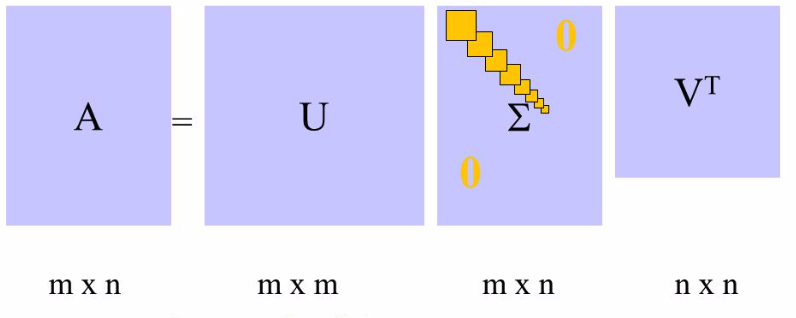

## Matrix Approximation Error

- So if we truncate the sum after \(k\) singular values, then we are approximating \(A\) with \(A_k\)

\[A_k = \Sigma_{i = 1}^{k<r} \sigma_i u_u v_i^T = \alpha_1 u_1 v_1^T + \cdots + \alpha_k u_k v_k^T.\]

- The error in the approximation is \(\sigma_{k+1}\).
- We have \(\text{rank}(A_k) = k < r = \text{rank}(A).\)
- By approximating \(A\) with \(A_k\), we have saved memory:
  - \(A\) requires us to store \(m\times n\) numbers
  - \(A_k\) requires us to store ??? numbers?

– Significant savings for large matrices, and/or small \(k\).

## Image Compression

## Image Compression

- Suppose we have a grayscale image (\(128 \times 128\) pixels).
  - We can use a matrix to represent this image.
- If we have a colour image, it has three matrices, with the same size as the image. Each matrix represents a color value that comprises the RGB color scale.
- Each pixel is represented by an integer from 0-255.
- Next, we can decompose the matrix by SVD.
- By eliminating small singular values, we can approximate the matrix.
  - Choose the value of \(k\) for the low-rank approximation \(A_k\).
  - Plotting the singular values might help identify where there is a noticeable drop in significance

## Reconstructing approximated image

- Suppose we have chosen the value of \(k\) = number of singular values we wish to retain. - We can generate a new image matrix by expanding \(A\) using the SVD (first \(k\) singular values only).
- If you want to use colour images, do it for R, G, B matrices separately and then reassemble.

## Data compression in R

Here are four images with rank 286, 200, 116 and 32. How many numbers to store for each of them?

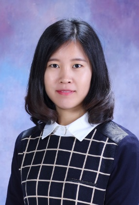

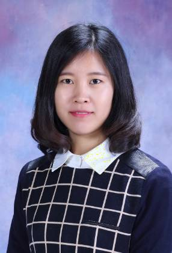

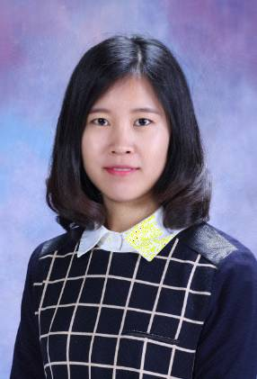

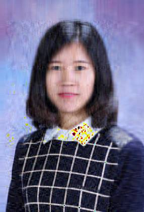

## Plot of singular values

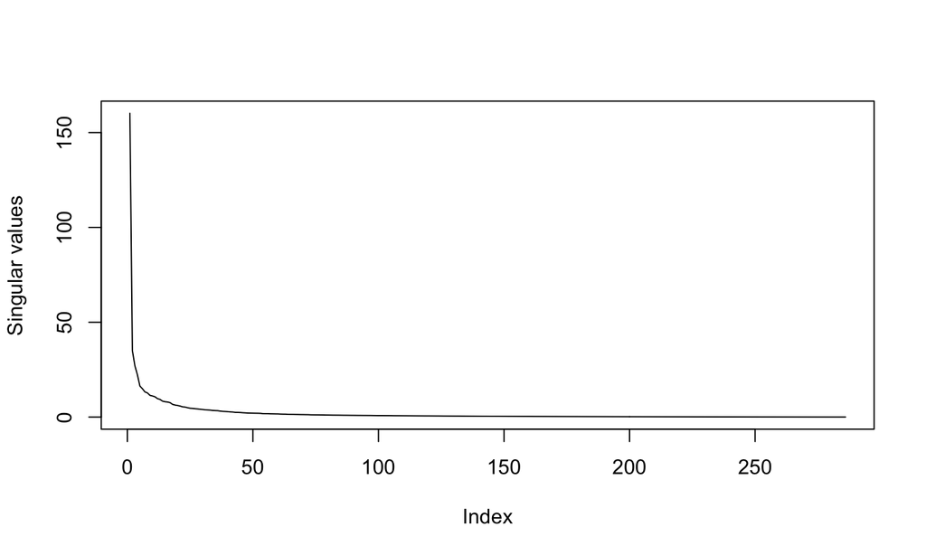

## Lab session

- Like in today’s lecture, take a high resolution image of yourself, and produce a sequence of low rank approximations.
- How much can you save?

## Noise reduction

## Noise reduction

- The SVD also has applications in digital signal processing
- The central idea is to let a matrix \(A\) represent the noisy signal, compute the SVD, and then discard small singular values of \(A\).
- It can be shown that the small singular values mainly represent the noise, and thus the rank \(k\) matrix \(A_k\) represents a filtered signal with less noise.

## Application to Signal Separation

- Suppose we have \(P\) observed signals \(m_i(t)\) which are linear combinations of r source signals \(s_i(t)\), corrupted by noise signals \(n_i(t)\). We have a time series of data from \(T\) time periods
- This can be written as: \[m_i(t) = \alpha_{i1}s_1(t) + \cdots + a_{ir}s_r(t) + n_i(t),\] where \(t = 1, \cdots, T\) and \(i = 1, \cdots, P\).
- Write the equivalent matrix representation.

## SVD of signal matrix \(M\)

- We can decompose \(M\) using SVD: \(M = U\Sigma V^T\).
- If the signal compared to the noise is sufficiently strong, we are likely to find clear distinction between the singular values due to the signal and those due to noise \[U = (U_s, U_n),~\Sigma = \left(\begin{array}{cc} \Sigma_s & \\ & \Sigma_n \end{array}\right),~V^T = \left(\begin{array}{c} V_s \\ V_n \end{array}\right)\]

## Results of noise reduction

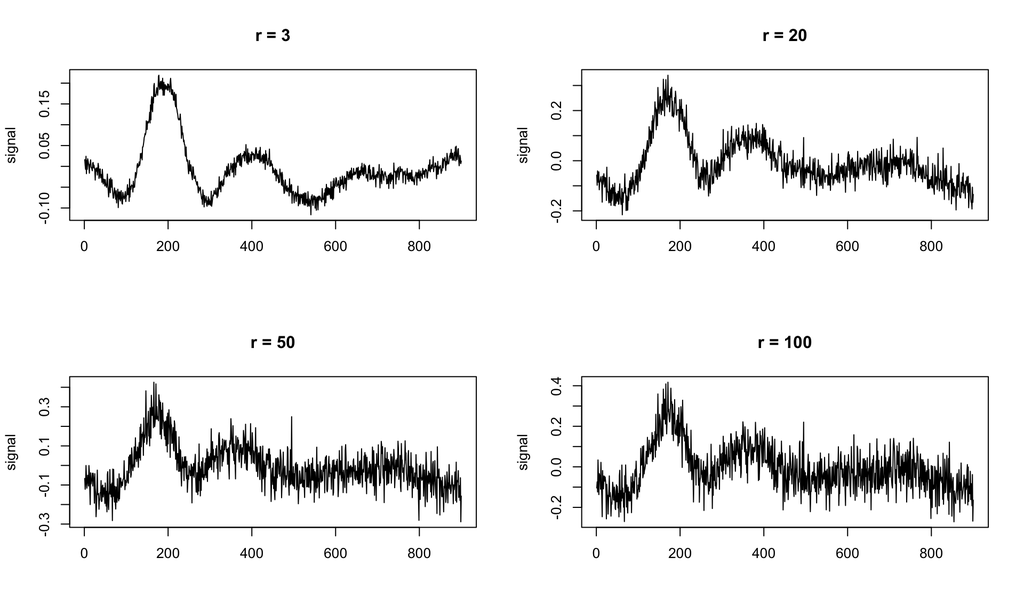

```r
library(bootSVD)
set.seed(1)
Y <- simEEG(n = 100, centered = TRUE, propVarNoise = 0.3, wide = TRUE)
svdY <- svd(Y)
par(mfrow = c(2, 2))
for (j in c(3, 20, 50, 100)) {
    a = svdY$u[, 1:j] %*% diag(svdY$d[1:j]) %*% t(svdY$v[, 1:j])
    plot(a[1, ], type = "l", xlab = "", ylab = "signal", main = paste("r = ",
        j, sep = ""))
}
```

## Curve fitting

## Curve fitting

- Curve fitting seeks to approximate the data by fitting a curve that minimises the sum of the squared residual errors.
- Over-determined linear system.
- No exact solutions.
- We find an approximation.

## Linear regression

For a linear regression, \[\mathbf{y} = \mathbf{X}\mathbf{\beta} + \mathbf{\varepsilon},~\mathbf{\epsilon}\sim N(0,\Sigma).\] what is its OLS solution?

## Numerical Issues

- Numerically, there can be problems with solving for \(\mathbf{\beta}\) via the normal equations.
  - The inverse of \(X^TX\) might not exist
  - It is not computationally efficient to invert it for large dimensions
  - \(X^TX\) maybe ill-conditioned
- The SVD can help us by providing a numerically stable pseudo-inverse, and the opportunity to identify (through the singular values) any ill-conditioning.

## Pseudo-inverse

Recall that the SVD of a matrix \(A\) in \(\mathcal{R}_{m\times n}\) decomposes the matrix into \[A = U\Sigma V^T = \left(\begin{array}{cc}U_1 & U_2\end{array}\right) \left(\begin{array}{cc} D & \\ & 0 \end{array}\right) \left(\begin{array}{cc}V_1^T & V_2^T\end{array}\right) = U_1DV_1^T\] where \(D = \text{diag}\{\alpha_1, \cdots, \alpha_r\} \in \mathcal{R}^{r\times r}\) with \(\sigma_r > 0\) for \(r = \text{rank}(A)\).

- The pseudo-inverse, or generalised inverse, of \(A\) can always be calculated, even if \(A\) is not invertible. \[A^+ = V_1D^{-1}U_1^T\]
- \(A^{+}\) is \(n \times m\).

## Linear regression

For \[\mathbf{y} = \mathbf{X}\mathbf{\beta} + \mathbf{\varepsilon},~\mathbf{\epsilon}\sim N(0,\Sigma),\] the solution is \[\beta = X^{+}y = V_1D^{-1}U_1^T y = \Sigma_{i = 1}^r \frac{v_iu_i^Ty}{\sigma_i}.\] A small singular value means trouble. A lower rank approximation should be more reliable.

## An example of using generalised inverse

```r
X <- matrix(c(1, 2, 4, 8, 3, 6, 9, 12, -11, -22, -32, -40), 4,
    3)
y <- 2 * X[, 1] - 7 * X[, 2] + 1e-04 * (rnorm(4) - 0.5)
library(MASS)
beta <- ginv(X) %*% y  # write your own function to find generalised inverse
t(y - X %*% beta) %*% (y - X %*% beta)
```

```
##              [,1]
## [1,] 3.845924e-08
```

## Lab session

- Use generalised inverse to solve a linear regression problem, and compare with the `lm()` function in R.